# HW3_490IDS_ddu2

Danning Du

September 20, 2016

##### Main topic: Using the “apply” family function

## Exercises

1. *(5 pts)* Given a function below,

```r
myfunc <- function(z) return(c(z,z^2, z^3%/%2))
```

(1). Examine the following code, and briefly explain what it is doing.

```r
y = 2:8
myfunc(y)
```

```
##  [1]   2   3   4   5   6   7   8   4   9  16  25  36  49  64   4  13  32
## [18]  62 108 171 256
```

```r
matrix(myfunc(y),ncol=3)
```

```
##      [,1] [,2] [,3]
## [1,]    2    4    4
## [2,]    3    9   13
## [3,]    4   16   32
## [4,]    5   25   62
## [5,]    6   36  108
## [6,]    7   49  171
## [7,]    8   64  256
```

**Explanation**: myfunc(y) with y=2:8 generates a list of elements with the value of c(y,y^2, y^3%/%2)) that fill the matrix, ncol=3 specify the dimension of the matrix, which means the matrix has 3 columns. nrow is not specified in this code, so it is made to infer it from the length of data.

(2). Simplify the code in (1) using one of the “apply” functions and save the result as m.

```r
m <- t(apply(matrix(y),1,myfunc))
m
```

```
##      [,1] [,2] [,3]
## [1,]    2    4    4
## [2,]    3    9   13
## [3,]    4   16   32
## [4,]    5   25   62
## [5,]    6   36  108
## [6,]    7   49  171
## [7,]    8   64  256
```

(3). Find the row product of m.

```r
apply(m,1,prod)
```

```
## [1]     32    351   2048   7750  23328  58653 131072
```

(4). Find the column sum of m in two ways.

```r
apply(m,2,sum)
```

```
## [1]  35 203 646
```

```r
colSums(m)
```

```
## [1]  35 203 646
```

(5). Could you divide all the values by 2 in two ways?

```r
m/2
```

```
##      [,1] [,2]  [,3]
## [1,]  1.0  2.0   2.0
## [2,]  1.5  4.5   6.5
## [3,]  2.0  8.0  16.0
## [4,]  2.5 12.5  31.0
## [5,]  3.0 18.0  54.0
## [6,]  3.5 24.5  85.5
## [7,]  4.0 32.0 128.0
```

```r
t(sapply(y,myfunc))/2
```

```
##      [,1] [,2]  [,3]
## [1,]  1.0  2.0   2.0
## [2,]  1.5  4.5   6.5
## [3,]  2.0  8.0  16.0
## [4,]  2.5 12.5  31.0
## [5,]  3.0 18.0  54.0
## [6,]  3.5 24.5  85.5
## [7,]  4.0 32.0 128.0
```

2. *(8 pts)* Create a list with 2 elements as follows:

```r
l <- list(a = 1:10, b = 11:20)
```

(1). What is the product of the values in each element?

```r
lapply(l,prod)
```

```
## $a
## [1] 3628800
##
## $b
## [1] 670442572800
```

The product of the values in element a is 3628800, in element b is 670442572800.

(2). What is the (sample) variance of the values in each element?

```r
lapply(l,var)
```

```
## $a
## [1] 9.166667
##
## $b
## [1] 9.166667
```

The (sample) variance of the values in element a is 9.166667, in element b is 9.166667.

(3). What type of object is returned if you use lapply? sapply? Show your R code that finds these answers.

```r
class(lapply(l,prod))
```

```
## [1] "list"
```

```r
class(lapply(l,var))
```

```
## [1] "list"
```

```r
class(sapply(l,prod))
```

```
## [1] "numeric"
```

```r
class(sapply(l,var))
```

```
## [1] "numeric"
```

Use lapply: “list” is returned. Use sapply: “numeric” is returned.

Now create the following list:

```r
l.2 <- list(c = c(21:30), d = c(31:40))
```

(4). What is the sum of the corresponding elements of l and l.2, using one function call?

```r
mapply(sum, l$a, l$b, l.2$c, l.2$d)
```

```
##  [1]  64  68  72  76  80  84  88  92  96 100
```

(5). Take the log of each element in the list l:

```r
rapply(l,log)
```

```
##        a1        a2        a3        a4        a5        a6        a7
## 0.0000000 0.6931472 1.0986123 1.3862944 1.6094379 1.7917595 1.9459101
##        a8        a9       a10        b1        b2        b3        b4
## 2.0794415 2.1972246 2.3025851 2.3978953 2.4849066 2.5649494 2.6390573
##        b5        b6        b7        b8        b9       b10
## 2.7080502 2.7725887 2.8332133 2.8903718 2.9444390 2.9957323
```

(6). First change l and l.2 into matrixes, make each element in the list as column,

```r
l <- matrix(c(1:10, 11:20), nrow = 10, ncol = 2)
colnames(l) <- c("a","b")
l
```

```
##        a  b
##  [1,]  1 11
##  [2,]  2 12
##  [3,]  3 13
##  [4,]  4 14
##  [5,]  5 15
##  [6,]  6 16
##  [7,]  7 17
##  [8,]  8 18
##  [9,]  9 19
## [10,] 10 20
```

```r
l.2 <- matrix(c(21:30, 31:40), nrow = 10, ncol = 2)
colnames(l.2) <- c("c","d")
l.2
```

```
##        c  d
##  [1,] 21 31
##  [2,] 22 32
##  [3,] 23 33
##  [4,] 24 34
##  [5,] 25 35
##  [6,] 26 36
##  [7,] 27 37
##  [8,] 28 38
##  [9,] 29 39
## [10,] 30 40
```

Then, form a list named mylist using l,l.2 and m (from Question 1) (in this order).

```r
mylist <- list(l,l.2,m)
```

Then, select the first column of each elements in mylist in one function call (hint ‘[’ is the select operator).

```r
lapply(mylist,'[',,1)
```

```
## [[1]]
##  [1]  1  2  3  4  5  6  7  8  9 10
##
## [[2]]
##  [1] 21 22 23 24 25 26 27 28 29 30
##
## [[3]]
## [1] 2 3 4 5 6 7 8
```

3. *(3 pts)* Let’s load our friend family data again.

```r
load(url("http://courseweb.lis.illinois.edu/~jguo24/family.rda"))
```

(1). Find the mean bmi by gender in one function call.

```r
tapply(fbmi,fgender,mean)
```

```
##        m        f
## 25.73898 23.02564
```

(2). Could you get a vector of what the type of variables the dataset is made of？

```r
rapply(family,class)
```

```
## firstName    gender       age    height    weight       bmi    overWt
##  "factor"  "factor" "integer" "numeric" "integer" "numeric" "logical"
```

(3). Could you sort the firstName in height descending order?

```r
family[order(fheight,decreasing=TRUE),c("firstName","height")]
```

```
##    firstName height
## 3        Joe     73
## 10       Tom     71
## 1        Tom     70
## 6        Liz     68
## 7        Jon     68
## 9        Tim     68
## 4        Bob     67
## 11       Ann     67
## 12       Dan     66
## 13       Art     66
## 8        Sal     65
## 2        May     64
## 5        Sue     64
## 14       Zoe     62
```

4. *(2 pts)* There is a famous dataset in R called “iris.” It should already be loaded in R for you. If you type in ?iris you can see some documentation. Familiarize yourself with this dataset.

(1). Find the mean petal length by species.

```r
tapply(iris$Petal.Length,iris$Species,mean)
```

```
##     setosa versicolor  virginica
##      1.462      4.260      5.552
```

(2). Now obtain the sum of the first 4 variables, by species, but using only one function call.

```r
by(iris[,1:4],iris$Species,colSums)
```

```
## iris$Species: setosa
## Sepal.Length  Sepal.Width Petal.Length  Petal.Width
##        250.3        171.4         73.1         12.3
## --------------------------------------------------------
## iris$Species: versicolor
## Sepal.Length  Sepal.Width Petal.Length  Petal.Width
##        296.8        138.5        213.0         66.3
## --------------------------------------------------------
## iris$Species: virginica
## Sepal.Length  Sepal.Width Petal.Length  Petal.Width
##        329.4        148.7        277.6        101.3
```

5. *(2 pts)* Below are two statements, their results have different structure,

```r
lapply(1:4, function(x) x^3)
sapply(1:4, function(x) x^3)
```

Could you change one of them to make the two statements return the same results (type of object)?

Change lapply(1:4, function(x) x^3) to:

```r
as.numeric(lapply(1:4, function(x) x^3))
```

```
## [1]  1  8 27 64
```

Which is the same as:

```r
sapply(1:4, function(x) x^3)
```

```
## [1]  1  8 27 64
```

6. *(5 pts)* Using the family data, fit a linear regression model to predict weight from height. Place your code and output (the model) below.

```r
fit <- lm(weight~height,data=family)
fit
```

```
##
## Call:
## lm(formula = weight ~ height, data = family)
##
## Coefficients:
## (Intercept)       height
##    -455.666        9.154
```

How do you interpret this model?

```r
summary(fit)
```

```
##
## Call:
## lm(formula = weight ~ height, data = family)
##
## Residuals:
##     Min      1Q  Median      3Q     Max
## -27.554  -9.689  -0.055  11.944  23.214
##
## Coefficients:
##             Estimate Std. Error t value Pr(>|t|)
## (Intercept) -455.666    107.029  -4.257  0.00111 **
## height         9.154      1.594   5.741 9.29e-05 ***
## ---
## Signif. codes:  0 '***' 0.001 '**' 0.01 '*' 0.05 '.' 0.1 ' ' 1
##
## Residual standard error: 16.94 on 12 degrees of freedom
## Multiple R-squared:  0.7331, Adjusted R-squared:  0.7109
## F-statistic: 32.96 on 1 and 12 DF,  p-value: 9.287e-05
```

**Interpretation**: From this output, we have determined that the intercept is -455.666 and the coefficient for fheight is 9.154. Therefore, the complete regression equation is fweight = -455.666 + 9.154*fheight. This equation tells us that the predicted weight will increase by 9.154 for every 1 unit increase in the height. Also, as the p-value 9.287e-05 is much less than 0.05, we reject the null hypothesis that β = 0. Hence there is a significant relationship between height and weight in the linear regression model of the data set family.

Create a scatterplot of height vs weight. Add the linear regression line you found above.

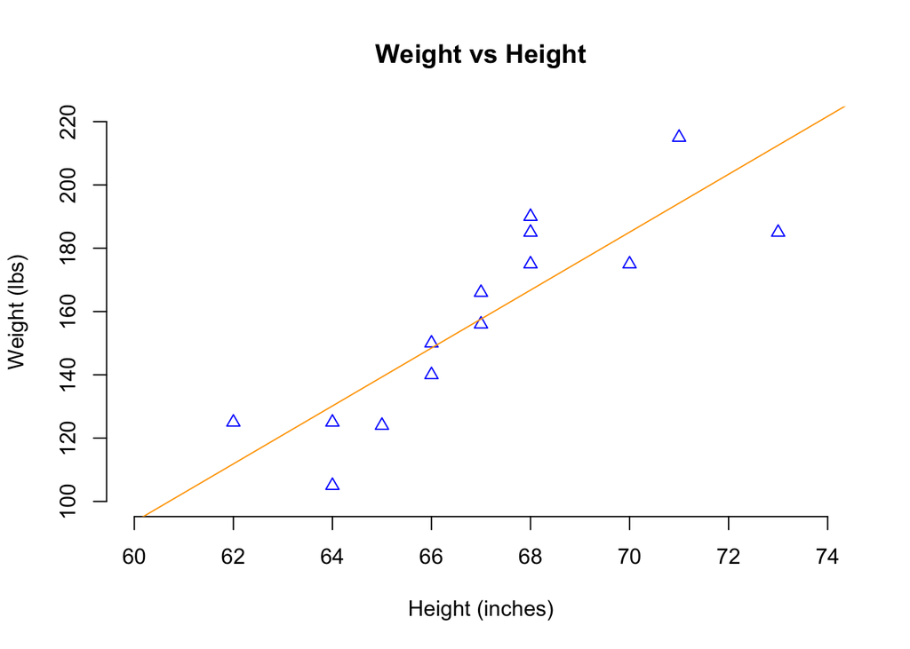

```r
plot(weight~height,data=family, xlab = "Height (inches)", ylab = "Weight (lbs)", xlim=c(60,74), ylim=c(100,220), pch=2, cex=1.0, frame.plot=FALSE, col="blue", main="Weight vs Height")
abline(fit,col="orange")
```

**Interpretation**: There is a positive association between height and weight. As height increases, weight increases. Also, as we can see, the blue dots are close to the orange linear regression line, so height and weight have a strong positive correlation.